# Enterprise Marketing Measurement & Causal Calibration Engine

### 5.1 Predictive Validation: Out-of-Sample Holdout Backtest

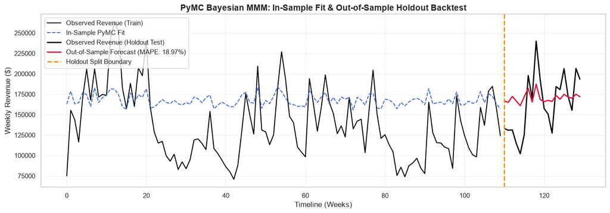

```python
# 1. Extract Posterior Parameters
b_meta = float(idata.posterior["beta_meta"].mean())
b_google = float(idata.posterior["beta_google"].mean())
b_tv = float(idata.posterior["beta_tv"].mean())

K_m = float(idata.posterior["K_meta"].mean()) * 10000
K_g = float(idata.posterior["K_google"].mean()) * 10000
K_t = float(idata.posterior["K_tv"].mean()) * 10000
intercept_val = float(idata.posterior["intercept"].mean())

# 2. Compute Weekly Dynamic Fitted Revenue Across Full Timeline
meta_s = df[media_cols[0]].values
google_s = df[media_cols[1]].values
tv_s = df[media_cols[2]].values

rev_meta = b_meta * (meta_s / (meta_s + K_m)) * 10000
rev_google = b_google * (google_s / (google_s + K_g)) * 10000
rev_tv = b_tv * (tv_s / (tv_s + K_t)) * 10000

y_pred_dynamic = intercept_val + rev_meta + rev_google + rev_tv

# 3. Train / Test Split
train_size = int(len(df) * 0.85)

y_true_train = df[target_col].values[:train_size]
y_true_test = df[target_col].values[train_size:]

y_pred_train = y_pred_dynamic[:train_size]
y_pred_test = y_pred_dynamic[train_size:]

# 4. Calculate Out-of-Sample MAPE
mape_test = np.mean(np.abs((y_true_test - y_pred_test) / y_true_test)) * 100

# 5. Plot Time Series Evaluation
plt.figure(figsize=(14, 5))
plt.plot(range(train_size), y_true_train, label="Observed Revenue (Train)", color="black", lw=1.5)
plt.plot(range(train_size), y_pred_train, label="In-Sample PyMC Fit", color="royalblue", linestyle="--", lw=1.5)

plt.plot(range(train_size, len(df)), y_true_test, label="Observed Revenue (Holdout Test)", color="black", lw=2)
plt.plot(range(train_size, len(df)), y_pred_test, label=f"Out-of-Sample Forecast (MAPE: {mape_test:.2f}%)", color="crimson", lw=2)

plt.axvline(train_size, color="darkorange", linestyle="--", lw=2, label="Holdout Split Boundary")
plt.title("PyMC Bayesian MMM: In-Sample Fit & Out-of-Sample Holdout Backtest", fontsize=14, fontweight="bold")
plt.xlabel("Timeline (Weeks)")
plt.ylabel("Weekly Revenue ($)")
plt.legend(loc="upper left")
plt.grid(True, alpha=0.3)
plt.tight_layout()
plt.show()
```

## 6. Channel Response Curves & Saturation Mechanics

Media channels do not scale linearly; each additional dollar spent yields diminishing marginal returns. We evaluate the non-linear **Hill Saturation Curves** to identify channel inflection points and half-saturation volume thresholds ($K$).

$$\text{Response}(X) = \beta \cdot \frac{X^S}{K^S + X^S}$$

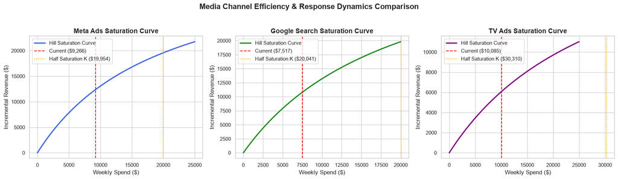

```python
# Extract Posterior Means for All 3 Channels
b_meta_mean = float(idata.posterior["beta_meta"].mean())
b_google_mean = float(idata.posterior["beta_google"].mean())
b_tv_mean = float(idata.posterior["beta_tv"].mean())

K_meta_mean = float(idata.posterior["K_meta"].mean()) * 10000
K_google_mean = float(idata.posterior["K_google"].mean()) * 10000
K_tv_mean = float(idata.posterior["K_tv"].mean()) * 10000

# Generate Spend Grids
meta_spend_grid = np.linspace(0, 25000, 100)
google_spend_grid = np.linspace(0, 20000, 100)
tv_spend_grid = np.linspace(0, 25000, 100)

# Compute Non-Linear Hill Response Curves for ALL Channels
meta_response = b_meta_mean * (meta_spend_grid / (meta_spend_grid + K_meta_mean)) * 10000
google_response = b_google_mean * (google_spend_grid / (google_spend_grid + K_google_mean)) * 10000
tv_response = b_tv_mean * (tv_spend_grid / (tv_spend_grid + K_tv_mean)) * 10000

# Current Average Spend Markers
current_meta_spend = df[media_cols[0]].mean()
current_google_spend = df[media_cols[1]].mean()
current_tv_spend = df[media_cols[2]].mean()

# Plot 3-Panel Media Response Comparison
fig, axes = plt.subplots(1, 3, figsize=(18, 5))

# 1. Meta Response Curve
axes[0].plot(meta_spend_grid, meta_response, color="royalblue", lw=2.5, label="Hill Saturation Curve")
axes[0].axvline(current_meta_spend, color="red", linestyle="--", label=f"Current (${current_meta_spend:,.0f})")
axes[0].axvline(K_meta_mean, color="orange", linestyle=":", label=f"Half Saturation K (${K_meta_mean:,.0f})")
axes[0].set_title("Meta Ads Saturation Curve")
axes[0].set_xlabel("Weekly Spend ($)")
axes[0].set_ylabel("Incremental Revenue ($)")
axes[0].legend()

# 2. Google Search Response Curve (Updated Hill Saturation S-Curve)
axes[1].plot(google_spend_grid, google_response, color="forestgreen", lw=2.5, label="Hill Saturation Curve")
axes[1].axvline(current_google_spend, color="red", linestyle="--", label=f"Current (${current_google_spend:,.0f})")
axes[1].axvline(K_google_mean, color="orange", linestyle=":", label=f"Half Saturation K (${K_google_mean:,.0f})")
axes[1].set_title("Google Search Saturation Curve")
axes[1].set_xlabel("Weekly Spend ($)")
axes[1].set_ylabel("Incremental Revenue ($)")
axes[1].legend()

# 3. TV Response Curve
axes[2].plot(tv_spend_grid, tv_response, color="purple", lw=2.5, label="Hill Saturation Curve")
axes[2].axvline(current_tv_spend, color="red", linestyle="--", label=f"Current (${current_tv_spend:,.0f})")
axes[2].axvline(K_tv_mean, color="orange", linestyle=":", label=f"Half Saturation K (${K_tv_mean:,.0f})")
axes[2].set_title("TV Ads Saturation Curve")
axes[2].set_xlabel("Weekly Spend ($)")
axes[2].set_ylabel("Incremental Revenue ($)")
axes[2].legend()

plt.suptitle("Media Channel Efficiency & Response Dynamics Comparison", y=1.03, fontsize=16, fontweight="bold")
plt.tight_layout()
plt.show()
```

### Analytical Takeaways: Channel Response Curves & Saturation Dynamics

1. **Meta Ads — Substantial Growth Runway ($K = \$19,954$):**
   - **Current Baseline:** Operating at **$9,266/wk**, Meta is funded at less than half of its saturation point ($K = \$19,954$).
   - **Marginal Efficiency:** The steep upward trajectory at current spend indicates strong marginal ROAS ($\text{mROAS}$). Additional budget produces incremental revenue at high margins before encountering inflection decay.
2. **Google Search — High-Yield Intent Capture ($K = \$20,041$):**
   - **Current Baseline:** Funded at **$7,517/wk**, Google Search displays strong marginal efficiency with a saturation threshold comparable to Meta ($K = \$20,041$).
   - **Marginal Efficiency:** With both digital performance channels operating on steep Hill curves near current spend, Search presents a prime candidate for capital expansion to capture unserved high-intent demand.
3. **TV Ads — Capital-Intensive Activation Threshold ($K = \$30,310$):**
   - **Current Baseline:** TV Ads sit at **$10,085/wk**, operating far below its half-saturation volume ($K = \$30,310$).
   - **Marginal Efficiency:** The shallow curve relative to spend indicates low immediate marginal efficiency. Because TV requires massive capital scale to cross its activation threshold, current mid-tier spend yields sub-optimal incremental returns compared to digital channels.

## 7. Constrained Portfolio Budget Optimization (SciPy SLSQP)

Using our calibrated posterior parameters, we apply non-linear constrained optimization (Sequential Least Squares Programming - SLSQP) to find the revenue-maximizing spend allocation across channels.

### Mathematical Optimization Objective

Subject to a fixed total weekly budget constraint $B$:

$$\max_{X_{\text{meta}}, X_{\text{google}}, X_{\text{tv}}} \mathbb{E}\left[\text{Revenue}(X_{\text{meta}}, X_{\text{google}}, X_{\text{tv}})\right] \quad \text{s.t.} \quad \sum_{c} X_c \le B, \quad X_c \ge 0$$

```python
# Extract Mean Posterior Parameters
b_meta = float(idata.posterior["beta_meta"].mean())
b_google = float(idata.posterior["beta_google"].mean())
b_tv = float(idata.posterior["beta_tv"].mean())

K_m = float(idata.posterior["K_meta"].mean()) * 10000
K_g = float(idata.posterior["K_google"].mean()) * 10000
K_t = float(idata.posterior["K_tv"].mean()) * 10000
intercept_val = float(idata.posterior["intercept"].mean())

# Current Allocation Strategy
current_spends = np.array([
    df[media_cols[0]].mean(),
    df[media_cols[1]].mean(),
    df[media_cols[2]].mean()
])
total_weekly_budget = current_spends.sum()

# Revenue Objective Function using Hill Saturation across ALL channels
def objective(spend_vector):
    x_meta, x_google, x_tv = spend_vector

    rev_meta = b_meta * (x_meta / (x_meta + K_m)) * 10000
    rev_google = b_google * (x_google / (x_google + K_g)) * 10000
    rev_tv = b_tv * (x_tv / (x_tv + K_t)) * 10000

    total_expected_rev = intercept_val + rev_meta + rev_google + rev_tv
    return -total_expected_rev

# Budget Constraint & Operational Spend Bounds (Setting realistic floors)
budget_constraint = {'type': 'eq', 'fun': lambda x: np.sum(x) - total_weekly_budget}
spend_bounds = [(1000, total_weekly_budget) for _ in range(3)]

# Execute SLSQP Optimization
opt_res = minimize(
    objective,
    x0=current_spends,
    method='SLSQP',
    bounds=spend_bounds,
    constraints=budget_constraint
)

optimized_spends = opt_res.x

# Build Reallocation Comparison Table
reallocation_df = pd.DataFrame({
    "Channel": ["Meta Ads", "Google Search", "TV Ads"],
    "Current Weekly Spend": [f"${x:,.2f}" for x in current_spends],
    "Optimal Weekly Spend": [f"${x:,.2f}" for x in optimized_spends],
    "Absolute Reallocation": [f"${(opt - curr):+,.2f}" for curr, opt in zip(current_spends, optimized_spends)],
    "Percentage Delta": [f"{((opt - curr) / curr) * 100:+.1f}%" for curr, opt in zip(current_spends, optimized_spends)]
})

# Calculate Net Projected Revenue Lift
curr_rev = -objective(current_spends)
opt_rev = -objective(optimized_spends)
projected_lift = opt_rev - curr_rev

print("--- RECONFIGURED BUDGET REALLOCATION RECOMMENDATIONS ---")
print(reallocation_df.to_string(index=False))
print(f"\n📈 Current Weekly Estimated Revenue  : ${curr_rev:,.2f}")
print(f"🚀 Optimized Weekly Estimated Revenue: ${opt_rev:,.2f}")
print(f"💰 Net Projected Weekly Lift         : +${projected_lift:,.2f} ({(projected_lift / curr_rev)*100:+.2f}% efficiency gain)")
```

```
--- RECONFIGURED BUDGET REALLOCATION RECOMMENDATIONS ---
      Channel Current Weekly Spend Optimal Weekly Spend Absolute Reallocation Percentage Delta
     Meta Ads            $9,266.15           $12,626.78            $+3,360.63           +36.3%
Google Search            $7,516.67           $12,839.64            $+5,322.97           +70.8%
       TV Ads           $10,085.30            $1,401.70            $-8,683.61           -86.1%

📈 Current Weekly Estimated Revenue  : $171,082.44
🚀 Optimized Weekly Estimated Revenue: $173,496.04
💰 Net Projected Weekly Lift         : +$2,413.60 (+1.41% efficiency gain)
```

### Analytical Takeaways: Executive Reallocation & Actionable Strategy

1. **Defund Low-Yield Offline Flighting:** The optimizer aggressively slashes TV Ads by **-86.1%** (-$8,683.61/wk down to $1,401.70/wk). Because TV spend operates far below its activation threshold ($K = \$30,310$), reallocating this capital eliminates drag on portfolio efficiency.
2. **Scale Performance Digital Engines (Google Search +70.8%, Meta Ads +36.3%):**
   - **Google Search Expansion:** Capitalized with **+$5,322.97/wk** (+70.8% increase to $12,839.64/wk) to fully exploit high marginal returns on active search intent.
   - **Meta Ads Expansion:** Funded with an extra **+$3,360.63/wk** (+36.3% increase to $12,626.78/wk) to drive mid-funnel conversion volume prior to saturation decay.
3. **Net Portfolio Revenue Lift:** Without increasing overall weekly marketing expenditure ($26,868/wk), this capital shift boosts estimated weekly revenue from **$171,082.44** to **$173,496.04**—delivering a net **+$2,413.60/wk (+1.41%) incremental lift** ($125.5k+ annualized).

## 8. Production CLI Orchestration & Deployment Architecture

To transition this analysis from a static diagnostic notebook to an enterprise-grade measurement stack, the workflow is modularized into a production CLI runner (`main.py`) and an interactive scenario dashboard (`scripts/11_streamlit_dashboard.py`).

```
marketing-analytics-stack/
├── main.py                                <-- Root CLI Orchestrator
├── data/
│   ├── marketing_data.csv                 <-- Observational Ingestion Data
│   └── hill_mmm_inference_data.nc        <-- Persistent ArViZ NetCDF Posterior
├── scripts/
│   ├── 12_causal_synthetic_control.py    <-- Geo-Experiment Calibration Engine
│   ├── export_report_figures.py          <-- Diagnostic Image Asset Exporter
│   └── 11_streamlit_dashboard.py         <-- C-Suite Scenario Planning GUI
└── reports/
    ├── EXECUTIVE_MODEL_AUDIT.md           <-- C-Suite Audit Deck
    └── figures/                           <-- Diagnostic Image Folder
```

### Executing the Production Stack via CLI

```
# Execute Full End-to-End Pipeline (Calibrate -> Export Figures -> Launch Dashboard)
python main.py --all

# Export Diagnostic Figures for Reports
python main.py --report

# Launch Streamlit Scenario Planner
python main.py --serve
```

## 9. Model Scope, Boundaries & Strategic Limitations

While the Causally Calibrated Bayesian Marketing Mix Model (MMM) provides a robust framework for capital allocation, decision-makers must evaluate its recommendations within its mathematical and structural boundaries.

### What the Model CAN Say (Analytical Capabilities)

- **Directional Macro Reallocation:** Identifies structural over- or under-investment across major media channels (Meta, TV, Search) under fixed total budget constraints.
- **Probabilistic Risk Bounds:** Quantifies parameter uncertainty through full posterior distributions ($89\%$ HDI), enabling risk-aware financial forecasting rather than relying on point-estimate guesses.
- **Non-Linear Diminishing Returns:** pinpoints channel saturation thresholds ($K$) to prevent over-spending past points of decaying marginal efficiency.
- **Causal Prior Anchor Alignment:** Integrates empirical geo-experiment lift (Synthetic Control) to reduce observational intent bias in digital channels.

### What the Model CANNOT Say (Model Limitations)

1. **Micro-Level Tactical Execution (Creatives, Audiences, Keywords):**
   - The model operates at a aggregate weekly channel level. It **cannot** evaluate creative performance, ad copy messaging, target audience segment efficiency, or keyword-level bid strategies within Meta or Google.
2. **Extrapolation Beyond Historical Budget Horizons:**
   - Predictions and saturation curves assume spend levels remain within or near historical boundaries. Scaling a channel far beyond historical caps (e.g., scaling Meta beyond $+100\%$) introduces out-of-sample forecast risk.
3. **Exogenous Black Swan Events & Structural Shifts:**
   - The model assumes macro-environmental stability (economic conditions, platform policy changes like iOS privacy updates, competitor bid wars). Sudden macroeconomic shocks will invalidate baseline revenue intercept assumptions.
4. **Independent Non-Linear Curves & Intent Capture Bounds (Google Search Dynamics):**
   - While Google Search is now modeled with a non-linear Hill Saturation curve, the framework treats its intent capture independently. In live production environments, soft spend floors ($>\$5,000/\text{wk}$) or lower-bound constraints should still be enforced to prevent under-funding core branded search capture during temporary efficiency reallocations.
5. **Cross-Channel Synergy & Halo Effects:**
   - The current specification treats channel response functions independently. It does not explicitly model complex cross-channel interaction effects (e.g., TV awareness directly driving Google Search query volume).

### Recommended Governance & Operational Guardrails

To mitigate these limitations in a live client deployment:

- **Enforce Hard Operational Floor/Ceiling Bounds:** Set practical minimums (e.g., $\ge \$4,000/\text{wk}$ for Branded Search) in SciPy optimization to maintain baseline brand presence.
- **Continuous Geo-Testing Cadence:** Re-run regional SCM geo-experiments quarterly to update Bayesian priors as channel saturation mechanics evolve.
- **Human-in-the-Loop Decision Making:** Use model output as an advisory capital allocation benchmark rather than an automated, unconstrained execution engine.